# Solution to Exercise 2.5

`Week B`

### 02409 Multivariate Statistics

The fitness data (the sundhed data in the stat2-folder) are from a study of how fast the body can absorb and use up oxygen. Data were collected as 31 subjects (in three groups, not considered here) were passed through an exercise run:

Variables (Description)

- Age (age in years)
- MaxPulse (maximum heart rate)
- Oxygen (oxygen consumption)
- RestPulse (heart rate while resting)
- RunPulse (heart rate while running)
- RunTime (minutes to run 1.5 miles)
- Weight (weight in kg)

```r
Fit <- data.frame("Age" = c(44,40,44,42,38,47,40,43,44,38,44,45,45,47,54,49,51,51,48,49,57,54,52,50,51,54,51,57,49,48,52),
                  "Weight" = c(89.47,75.07,85.84,68.15,89.02,77.45,75.98,81.19,81.42,81.87,73.03,87.66,66.45,79.15,83.12,81.42,69.63,77.91,91.63,73.37,73.37,79.38,76.32,70.87,67.25,91.63,73.71,59.08,76.32,61.24,82.78),
                  "Oxygen" = c(44.609,45.313,54.297,59.571,49.874,44.811,45.681,49.091,39.442,60.055,50.541,37.388,44.754,47.273,51.855,49.156,40.836,46.672,46.774,50.388,39.407,46.08,45.441,54.625,45.118,39.203,45.79,50.545,48.673,47.92,47.467),
                  "Runtime" = c(11.37,10.07,8.65,8.17,9.22,11.63,11.95,10.85,13.08,8.63,10.13,14.03,11.12,10.60,10.33,8.95,10.95,10.00,10.25,10.08,12.63,11.17,9.63,8.92,11.08,12.88,10.47,9.93,9.40,11.50,10.50),
                  "RestPulse" = c(62,62,45,40,55,58,70,64,63,48,45,56,51,47,50,44,57,48,48,67,58,62,48,48,48,44,59,49,56,52,53),
                  "RunPulse" = c(178,185,156,166,178,176,176,162,174,170,168,186,176,162,166,180,168,162,162,168,174,156,164,146,172,168,186,148,186,170,170),
                  "MaxPulse" = c(182,185,168,172,180,176,180,170,176,186,168,192,176,164,170,185,172,168,164,168,176,165,166,155,172,172,188,155,188,176,172))
```

**1. Use RStudio to find the correlation between the variables! Are there any significant ones?**

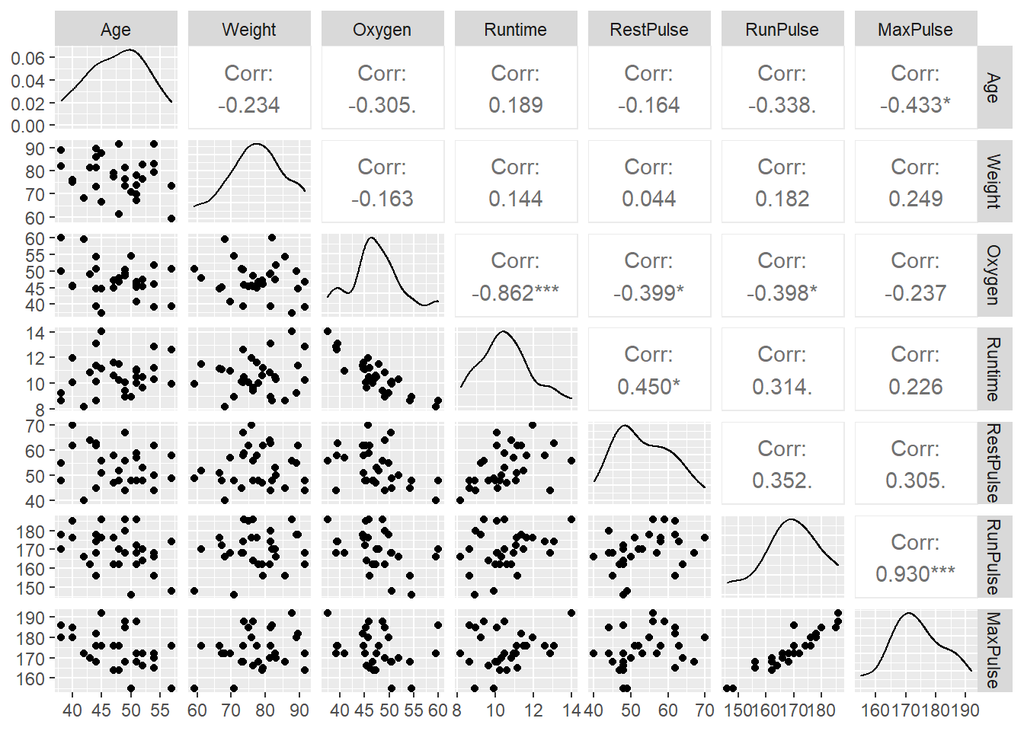

```r
ggpairs(Fit)
```

In the matrix of scatterplots we see that especially oxygen-runtime and runpulse-maxpulse are strongly correlated, the first with a negative correlation, the second with a positive correlation.

The conclusions drawn from the scatterplots are confirmed by the fact that the two correlations are by far the most significant ones, with -0.862 for oxygen-runtime and 0.930 for runpulse-maxpulse. The three stars next to their correlation values in the scatterplot indicate that the correlation is highly significant.

Additionally, we see four correlations that are significant, shown in the scatterplot with a single star.

**2. Find the partial correlation between variables conditioned on ‘Age’ and ‘Weight’! Are there interesting differences?**

```r
Fit_rcorr = as.matrix(Fit)
print("Pearson correlation coefficients and significance test:")
rcorr(Fit_rcorr)
```

```
## [1] "Pearson correlation coefficients and significance test:"
```

```
##             Age Weight Oxygen Runtime RestPulse RunPulse MaxPulse
## Age        1.00  -0.23  -0.30    0.19     -0.16    -0.34    -0.43
## Weight    -0.23   1.00  -0.16    0.14      0.04     0.18     0.25
## Oxygen    -0.30  -0.16   1.00   -0.86     -0.40    -0.40    -0.24
## Runtime    0.19   0.14  -0.86    1.00      0.45     0.31     0.23
## RestPulse -0.16   0.04  -0.40    0.45      1.00     0.35     0.31
## RunPulse  -0.34   0.18  -0.40    0.31      0.35     1.00     0.93
## MaxPulse  -0.43   0.25  -0.24    0.23      0.31     0.93     1.00
##
## n= 31
##
##
## P
##           Age    Weight Oxygen Runtime RestPulse RunPulse MaxPulse
## Age              0.2061 0.0957 0.3092  0.3777    0.0630   0.0150
## Weight    0.2061        0.3817 0.4412  0.8143    0.3284   0.1761
## Oxygen    0.0957 0.3817        0.0000  0.0260    0.0266   0.1997
## Runtime   0.3092 0.4412 0.0000         0.0110    0.0858   0.2213
## RestPulse 0.3777 0.8143 0.0260 0.0110            0.0518   0.0951
## RunPulse  0.0630 0.3284 0.0266 0.0858  0.0518             0.0000
## MaxPulse  0.0150 0.1761 0.1997 0.2213  0.0951    0.0000
```

```r
# number of observations
n = 31
# number of variables partialled out
s = 2
Fit_Partial = partial.r(Fit,c(3:7),c(1:2))

Partial_Corr = corr.p(Fit_Partial,n-s,adjust="none")
print("Pearson Partial correlation coefficients and significance test:")
Partial_Corr
# More specifically:
print("Two newly significant correlations:")
Partial_Corr$p[1,5]
Partial_Corr$p[2,4]
```

```
## [1] "Pearson Partial correlation coefficients and significance test:"
```

```
## Call:corr.p(r = Fit_Partial, n = n - s, adjust = "none")
## Correlation matrix
## partial correlations
##           Oxygen Runtime RestPulse RunPulse MaxPulse
## Oxygen      1.00   -0.85     -0.49    -0.55    -0.41
## Runtime    -0.85    1.00      0.51     0.40     0.33
## RestPulse  -0.49    0.51      1.00     0.32     0.27
## RunPulse   -0.55    0.40      0.32     1.00     0.92
## MaxPulse   -0.41    0.33      0.27     0.92     1.00
## Sample Size
## [1] 29
## partial correlations
##           Oxygen Runtime RestPulse RunPulse MaxPulse
## Oxygen      0.00    0.00      0.01     0.00     0.03
## Runtime     0.00    0.00      0.01     0.03     0.08
## RestPulse   0.01    0.01      0.00     0.09     0.16
## RunPulse    0.00    0.03      0.09     0.00     0.00
## MaxPulse    0.03    0.08      0.16     0.00     0.00
##
##  To see confidence intervals of the correlations, print with the short=FALSE option
```

```
## [1] "Two newly significant correlations:"
```

```
## [1] 0.02913625
```

```
## [1] 0.03322062
```

In SAS, a Scatter Plot Matrix of the Partialled Residuals can be chosen as an output. A way to get them in R is to make linear models conditioned on Age and Weight, and plot their residuals against each other:

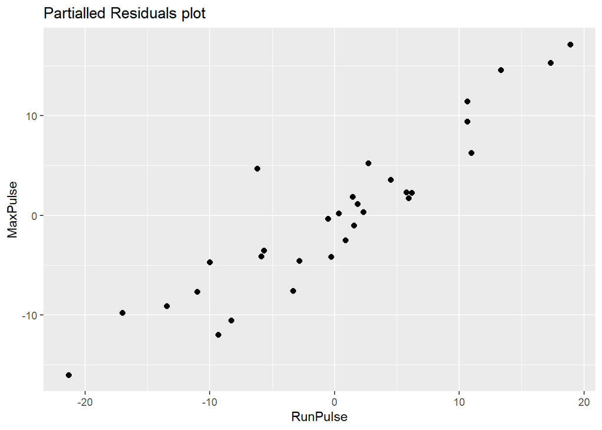

```r
lm_RunPulse <- lm(RunPulse~ Age + Weight, data = Fit)
lm_MaxPulse<- lm(MaxPulse~ Age + Weight, data = Fit)

ggplot(Fit,aes(x=lm_RunPulse$residuals,y=lm_MaxPulse$residuals))+
  geom_point(size=3, shape=20)+
  ggtitle("Partialled Residuals plot")+
  ylab("MaxPulse")+xlab("RunPulse")
```

In order to see the changes in the correlation matrices after conditioning the variables on “Age” and “Weight”, we plot the partialled residual scatter plot for oxygen-maxpulse.

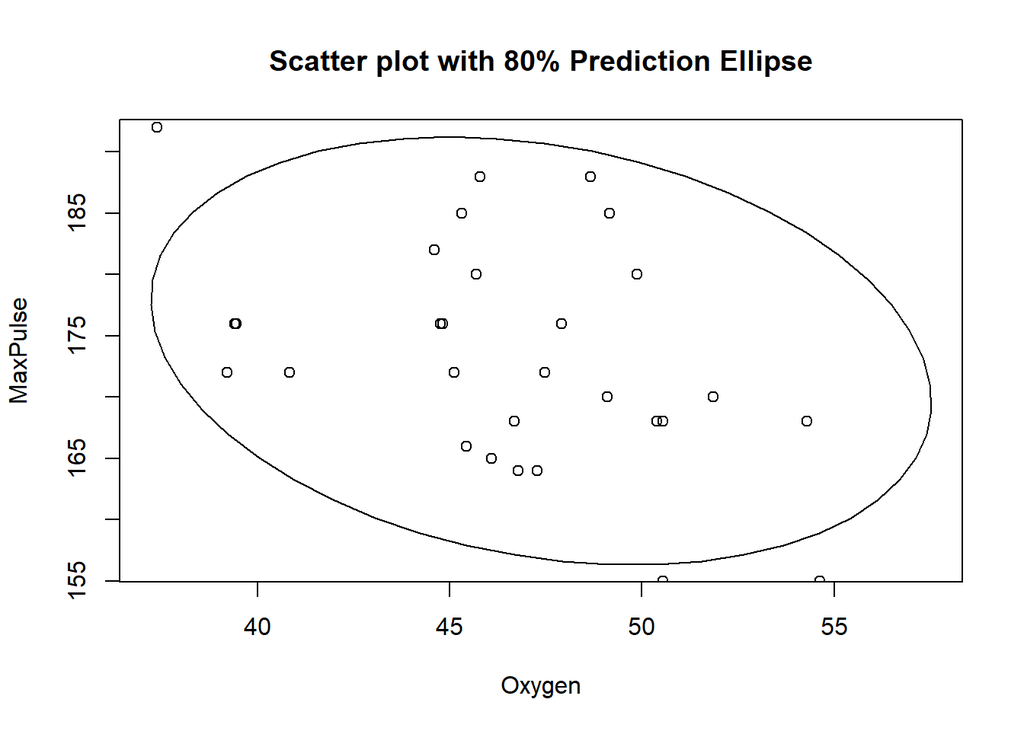

```r
# 80% prediction ellipse for scatter plot
# Code by Rolf Turner https://stat.ethz.ch/pipermail/r-help/2013-February/346995.html
npts   <- length(Fit$Oxygen)
shape  <- var(cbind(Fit$Oxygen, Fit$MaxPulse))
center <- c(mean(Fit$Oxygen),mean(Fit$MaxPulse))
rconf  <- sqrt(2 * (npts-1) * qf(0.8, 2, npts-2)/(npts*(npts-2)))
rpred  <- sqrt(npts+1)*rconf

conf.elip <- ellipse(center, shape, rconf,draw = FALSE)
pred.elip <- ellipse(center, shape, rpred,draw = FALSE)
plot(pred.elip, type='l', main = 'Scatter plot with 80% Prediction Ellipse', xlab = "Oxygen", ylab = "MaxPulse")
points(Fit$Oxygen, Fit$MaxPulse)
```

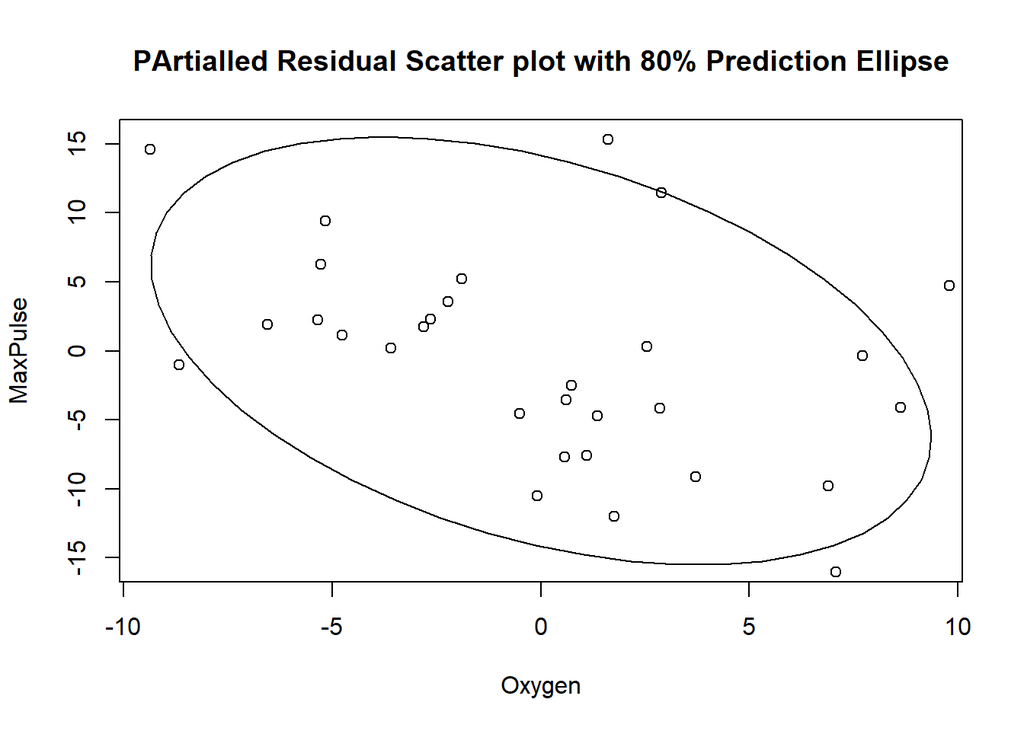

```r
# 80% prediction ellipse for partialled residual scatter plot
lm_MaxPulse<- lm(MaxPulse~ Age + Weight, data = Fit)
lm_Oxygen <- lm(Oxygen~ Age + Weight, data = Fit)

# 80% prediction ellipse for scatter plot
# Code by Rolf Turner https://stat.ethz.ch/pipermail/r-help/2013-February/346995.html
npts   <- length(lm_Oxygen$residuals)
shape  <- var(cbind(lm_Oxygen$residuals, lm_MaxPulse$residuals))
center <- c(mean(lm_Oxygen$residuals),mean(lm_MaxPulse$residuals))
rconf  <- sqrt(2 * (npts-1) * qf(0.8, 2, npts-2)/(npts*(npts-2)))
rpred  <- sqrt(npts+1)*rconf

conf.elip <- ellipse(center, shape, rconf,draw = FALSE)
pred.elip <- ellipse(center, shape, rpred,draw = FALSE)
plot(pred.elip, type='l', main = 'PArtialled Residual Scatter plot with 80% Prediction Ellipse', xlab = "Oxygen", ylab = "MaxPulse")
points(lm_Oxygen$residuals, lm_MaxPulse$residuals)
```

**3. Make a plot of oxygen as function of runtime! Does the plot look as expected?**

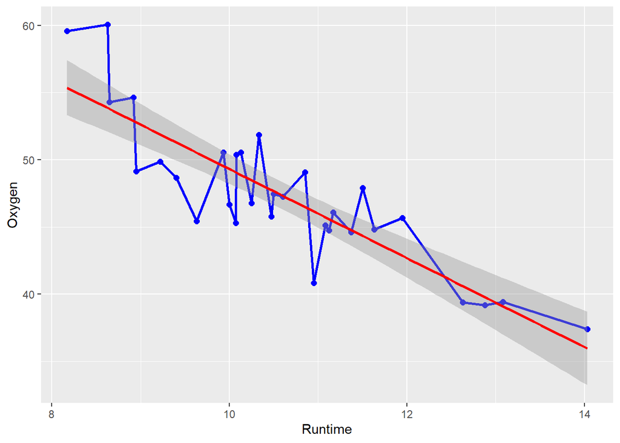

```r
ggplot(Fit,aes(x=Runtime,y=Oxygen))+
  geom_line(size=1,col='blue')+
  geom_point(size=2,col='blue')+
  geom_smooth(method='lm',formula = y~x,col='red')
```

The above plot presents the data (in blue) and the regression line for Oxygen against Runtime.